# Probability of Device's Failure

**Premise:** A company has a fleet of devices transmitting daily aggregated telemetry attributes. Predictive maintenance techniques are designed to help determine the condition of in-service equipment in order to predict when maintenance should be performed. This promises cost saving over routine or time-based preventive maintenance should be performed. This approach promises cost savings over routine or time-based preventive mainteance, because tasks are performed only when warranted

## 1. Overview:

- The purpose of this project is to determine the chance of device's failure ultilizing Machine Learning Technique.
- In addition, glancing through the set of data, each row of the original data represents a record of the status of a devices which listed in attributes # at the end of the day
- By determining how each attributes change, we can create a Machine learning model that would predict the probability of devices' failure

## 2. Import Libraries and Data

### 2.1 Libraries

```python
import numpy as np
import pandas as pd
import matplotlib.pyplot as plt
import seaborn as sns
from sklearn.ensemble import GradientBoostingClassifier, AdaBoostClassifier
from sklearn.metrics import accuracy_score, recall_score, f1_score, precision_score
from sklearn.linear_model import LogisticRegression
from sklearn.model_selection import KFold, cross_val_score, train_test_split, GridSearchCV
from scipy.stats import linregress
from datetime import datetime as dt
from sklearn.metrics import classification_report
from sklearn.model_selection import GridSearchCV
import xgboost
%matplotlib inline
```

### 2.2 Data

```python
df = pd.read_csv('project4.csv')
```

```python
df.head()
```

|  | date | device | failure | attribute1 | attribute2 | attribute3 | attribute4 | attribute5 | attribute6 | attribute7 | attribute8 | attribute9 |
| --- | --- | --- | --- | --- | --- | --- | --- | --- | --- | --- | --- | --- |
| 0 | 2015-01-01 | S1F01085 | 0 | 215630672 | 56 | 0 | 52 | 6 | 407438 | 0 | 0 | 7 |
| 1 | 2015-01-01 | S1F0166B | 0 | 61370680 | 0 | 3 | 0 | 6 | 403174 | 0 | 0 | 0 |
| 2 | 2015-01-01 | S1F01E6Y | 0 | 173295968 | 0 | 0 | 0 | 12 | 237394 | 0 | 0 | 0 |
| 3 | 2015-01-01 | S1F01JE0 | 0 | 79694024 | 0 | 0 | 0 | 6 | 410186 | 0 | 0 | 0 |
| 4 | 2015-01-01 | S1F01R2B | 0 | 135970480 | 0 | 0 | 0 | 15 | 313173 | 0 | 0 | 3 |

```python
df.info()
```

```
<class 'pandas.core.frame.DataFrame'>
RangeIndex: 124494 entries, 0 to 124493
Data columns (total 12 columns):
date          124494 non-null object
device        124494 non-null object
failure       124494 non-null int64
attribute1    124494 non-null int64
attribute2    124494 non-null int64
attribute3    124494 non-null int64
attribute4    124494 non-null int64
attribute5    124494 non-null int64
attribute6    124494 non-null int64
attribute7    124494 non-null int64
attribute8    124494 non-null int64
attribute9    124494 non-null int64
dtypes: int64(10), object(2)
memory usage: 11.4+ MB
```

### 3. Data Analysis

### 3.1 Unique Data

```python
device_fail = df['device'][df['failure']==1]
device_fail = list(device_fail)
```

```python
df.nunique()
```

```
date             304
device          1168
failure            2
attribute1    123878
attribute2       558
attribute3        47
attribute4       115
attribute5        60
attribute6     44838
attribute7        28
attribute8        28
attribute9        65
dtype: int64
```

Total data was record in an interval of 304 days (less than a year). There are many columns with less than 50 unique values. Something worth to investigate

One thing we need to determine before training the model: Is any of these features categorical? For example, one attribute could mean type of error it is getting. Another could mean thermal level. Another could mean signal strength.

```python
df.shape[0]
```

```
124494
```

### 3.2 Failure Rate

```python
df.failure.value_counts()
```

```
0    124388
1       106
Name: failure, dtype: int64
```

It seems that there are less than 1% of records have failure. This is not helpful since it showed tremendous amount of imbalanced Data. Lets do group by device to get a clearer picture

```python
df_rate = df.groupby('device').sum().reset_index()
df_rate = df_rate.loc[:,['device', 'failure']]
```

```python
df_rate.failure.value_counts()
```

```
0    1062
1     106
Name: failure, dtype: int64
```

As we can see, there are 106 failed devices and 1062 devices operate normally

## 4. Feature Engineer:

Convert attributes into log values

```python
for i in df.columns:
    if i not in ['device', 'failure', 'date']:
        df[i] = np.log1p(df[i])
```

Convert date into date type then to ordinal format

```python
df['date'] = pd.to_datetime(df['date'])
df['date']=df['date'].apply(lambda x: x.toordinal())
```

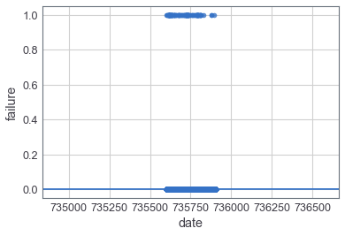

```python
sns.regplot(x=df['date'], y=df['failure'])
```

From the chart above, we can see that there are certain time periods where a lot of devices would failed. We will adding couple of features that represent the months that devices were online.

```python
date_max = df.groupby(by='device').max()
```

```python
date_max['month'] = date_max.date.apply(lambda x: dt.fromordinal(x).month)
```

What I just did was converting the last day of each device data was recorded to month. This will help us determine what month it would fail.

Create new DataFrame based on show each device with its slope based on day

```python
slope_final = pd.DataFrame([])
for column in df.columns:
    if column not in ['date', 'device','failure']:
        slope_df = df.groupby(by='device').apply(lambda x: linregress(x.date,x[column])[0])
        slope_final = pd.concat([slope_final,slope_df.rename(column)],axis =1)
failure = df.groupby(by='device').sum()
slope_final = pd.concat([slope_final,failure['failure'].rename('failure')],axis =1)
date =  df.groupby(by='device').count()
slope_final = pd.concat([slope_final,date['date'].rename('date')],axis =1)
slope_final = slope_final.reset_index()
```

```python
slope_final.head()
```

|  | device | attribute1 | attribute2 | attribute3 | attribute4 | attribute5 | attribute6 | attribute7 | attribute8 | attribute9 | failure | date |
| --- | --- | --- | --- | --- | --- | --- | --- | --- | --- | --- | --- | --- |
| 0 | S1F01085 | 0.276836 | 0.0 | 0.0 | 0.0 | 0.0 | 0.000830 | 0.0 | 0.0 | 0.0 | 0 | 6 |
| 1 | S1F013BB | 0.352332 | 0.0 | 0.0 | 0.0 | 0.0 | 0.000060 | 0.0 | 0.0 | 0.0 | 0 | 6 |
| 2 | S1F0166B | -0.286422 | 0.0 | 0.0 | 0.0 | 0.0 | 0.000706 | 0.0 | 0.0 | 0.0 | 0 | 6 |
| 3 | S1F01E6Y | -0.001215 | 0.0 | 0.0 | 0.0 | 0.0 | 0.001591 | 0.0 | 0.0 | 0.0 | 0 | 48 |
| 4 | S1F01JE0 | 0.152268 | 0.0 | 0.0 | 0.0 | 0.0 | 0.000829 | 0.0 | 0.0 | 0.0 | 0 | 6 |

### 5. Modeling

#### 5.1 Define Function to be used later:

```python
def score_result(y, pred):
    print 'Precision Score is', precision_score(y, pred)
    print 'Recall Score is', recall_score(y, pred)
    print 'f1_score is ', f1_score(y, pred)

def f1_score_1(model, fold = 5):
    f1_score = cross_val_score(estimator=model, cv=fold,X=x, y=y,scoring='f1')
    return f1_score
def precision_1(model, fold = 5):
    precision = cross_val_score(estimator=model, cv=fold,X=x, y=y,scoring='precision')
    return precision
def recall_s(model, fold = 5):
    recall_s = cross_val_score(estimator=model, cv=fold,X=x, y=y,scoring='recall')
    return recall_s
def Scoring(model):
    print "f1 score is: ", f1_score_1(model).mean()
    print "precision is: ", precision_1(model).mean()
    print "recall is: ", recall_s(model).mean()

def modelfit(alg, dtrain, target, performCV=True, printFeatureImportance=True, cv_folds=5):
    #Fit the algorithm on the data
    alg.fit(dtrain, target)

    #Predict training set:
    dtrain_predictions = alg.predict(dtrain)
    dtrain_predprob = alg.predict_proba(dtrain)[:,1]

    #Perform cross-validation:
    if performCV:
        cv_score = cross_val_score(alg, dtrain, target, cv=cv_folds, scoring='recall')

    #Print model report:
    if performCV:
        print "CV Score : Mean - %.7g | Std - %.7g | Min - %.7g | Max - %.7g" % (np.mean(cv_score),np.std(cv_score),np.min(cv_score),np.max(cv_score))

    #Print Feature Importance:
    if printFeatureImportance:
        #feat_imp = pd.Series(alg.feature_importances_, dtrain.columns.tolist()).sort_values(ascending=False)
        #feat_imp.plot(kind='bar', title='Feature Importances')
        #plt.ylabel('Feature Importance Score')
        feat_imp = pd.DataFrame(alg.feature_importances_, columns=['value'])
        x_columns = pd.DataFrame(dtrain.columns, columns = ['feature'])
        feat_imp = pd.concat([x_columns,feat_imp], axis = 1).sort_values(by = 'value', ascending = False)
        feat_imp = feat_imp.head(12)
        sns.barplot(x = feat_imp['value'], y = feat_imp['feature']).set_title('Feature Importance Score')
```

```python
x = slope_final.drop(['device', 'failure'], axis =1)
y = slope_final['failure']
for i in ['attribute7', 'attribute8', 'attribute1', 'attribute2']:
    x[i]= x[i]**3
```

```python
slope_final.head()
```

|  | device | attribute1 | attribute2 | attribute3 | attribute4 | attribute5 | attribute6 | attribute7 | attribute8 | attribute9 | failure | date |
| --- | --- | --- | --- | --- | --- | --- | --- | --- | --- | --- | --- | --- |
| 0 | S1F01085 | 0.276836 | 0.0 | 0.0 | 0.0 | 0.0 | 0.000830 | 0.0 | 0.0 | 0.0 | 0 | 6 |
| 1 | S1F013BB | 0.352332 | 0.0 | 0.0 | 0.0 | 0.0 | 0.000060 | 0.0 | 0.0 | 0.0 | 0 | 6 |
| 2 | S1F0166B | -0.286422 | 0.0 | 0.0 | 0.0 | 0.0 | 0.000706 | 0.0 | 0.0 | 0.0 | 0 | 6 |
| 3 | S1F01E6Y | -0.001215 | 0.0 | 0.0 | 0.0 | 0.0 | 0.001591 | 0.0 | 0.0 | 0.0 | 0 | 48 |
| 4 | S1F01JE0 | 0.152268 | 0.0 | 0.0 | 0.0 | 0.0 | 0.000829 | 0.0 | 0.0 | 0.0 | 0 | 6 |

#### List of Model and their initialization:

```python
xgc = xgboost.XGBClassifier(n_estimators = 150, learning_rate = 0.1)
gbc = GradientBoostingClassifier(learning_rate=0.1, n_estimators=120, max_depth=3, min_samples_leaf=30, min_samples_split=5, subsample=0.9)
ada = AdaBoostClassifier(learning_rate = 0.4, n_estimators=100)
models_list = (xgc, gbc, ada)
```

#### Start Cross validation between different Models

```
XGB:
f1 score is:  0.753271796956
precision is:  0.865392648287
recall is:  0.67012987013
Gradient Boost:
f1 score is:  0.643507618508
precision is:  0.733158530384
recall is:  0.574458874459
AdaBoost:
f1 score is:  0.572344947421
precision is:  0.810637254902
recall is:  0.461038961039
CV Score : Mean - 0.6701299 | Std - 0.1029684 | Min - 0.5238095 | Max - 0.8095238
```

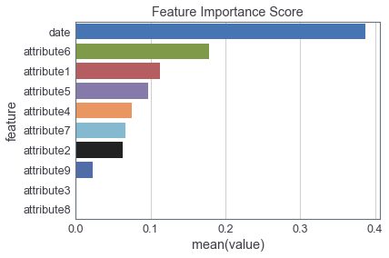

```python
print "XGB: "
Scoring(xgc)
print "Gradient Boost: "
Scoring(gbc)
print "AdaBoost: "
Scoring(ada)

modelfit(xgc, x, y)
```

### ReFeature Engineering to improve Score

##### Using groupby mean()

```
XGB:
f1 score is:  0.629384445174
precision is:  0.724068627451
recall is:  0.557142857143
None
Gradient Boost:
f1 score is:  0.621865474497
precision is:  0.687091503268
recall is:  0.574891774892
None
AdaBoost:
f1 score is:  0.364972721013
precision is:  0.619047619048
recall is:  0.264935064935
None
CV Score : Mean - 0.5571429 | Std - 0.05947617 | Min - 0.4761905 | Max - 0.6190476
```

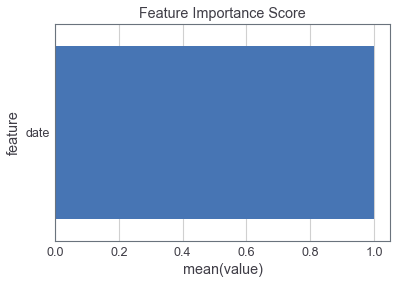

```python
slope_final = pd.DataFrame([])
slope_df = df.groupby(by='device').mean()
failure = df.groupby(by='device').sum()
slope_final = pd.concat([slope_df.drop(['failure','date'], axis =1),failure['failure'].rename('failure')],axis =1)
date =  df.groupby(by='device').count()
slope_final = pd.concat([slope_final,date['date'].rename('date')],axis =1)
slope_final = slope_final.reset_index()

x = slope_final.loc[:, ['date']]
y = slope_final['failure']

print "XGB: "
print Scoring(xgc)

print "Gradient Boost: "
print Scoring(gbc)

print "AdaBoost: "
print Scoring(ada)

modelfit(xgc, x, y)
```

###### Using Group by sum()

```python
slope_final = pd.DataFrame([])
slope_df = df.groupby(by='device').sum()
failure = df.groupby(by='device').sum()
slope_final = pd.concat([slope_df.drop(['failure','date'], axis =1),failure['failure'].rename('failure')],axis =1)
date =  df.groupby(by='device').count()
slope_final = pd.concat([slope_final,date['date'].rename('date')],axis =1)
slope_final = slope_final.reset_index()


x = slope_final.drop(['failure','device'], axis =1)
y = slope_final['failure']

print "XGB: "
print Scoring(xgc)

print "Gradient Boost: "
print Scoring(gbc)

print "AdaBoost: "
print Scoring(ada)
```

```
XGB:
f1 score is:  0.646649419304
precision is:  0.80533022533
recall is:  0.55670995671
None
Gradient Boost:
f1 score is:  0.6913003663
precision is:  0.781403508772
recall is:  0.64025974026
None
AdaBoost:
f1 score is:  0.676845658509
precision is:  0.823692810458
recall is:  0.584415584416
None
```

We will use PCA to reduce atribute 3 and 8 into one feature to see if the score will improve

```python
from sklearn.decomposition import PCA
pca = PCA(n_components=1)
pca.fit(df.loc[:,['attribute3', 'attribute8']])
X_new = pca.transform(df.loc[:,['attribute3', 'attribute8']])
X_new = pd.DataFrame(X_new, columns=['attribute3+8'])
df = df.join(X_new)
df = df.drop(['attribute3', 'attribute8'], axis =1)
```

```
XGB:
f1 score is:  0.784160401003
precision is:  0.88512605042
recall is:  0.706926406926
Gradient Boost:
f1 score is:  0.742795716621
precision is:  0.846395400265
recall is:  0.660173160173
AdaBoost:
f1 score is:  0.64804972805
precision is:  0.827581699346
recall is:  0.545887445887
CV Score : Mean - 0.7069264 | Std - 0.1154441 | Min - 0.5238095 | Max - 0.8095238
```

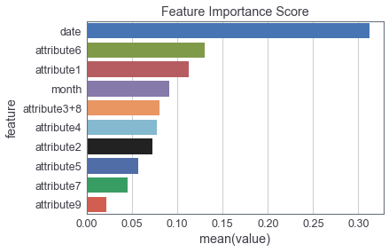

```python
df2 = df
slope_final = pd.DataFrame([])
for column in df2.columns:
    if column not in ['date', 'device','failure']:
        slope_df = df2.groupby(by='device').apply(lambda x: linregress(x.date,x[column])[0])
        slope_final = pd.concat([slope_final,slope_df.rename(column)],axis =1)
failure = df.groupby(by='device').sum()
slope_final = pd.concat([slope_final,failure['failure'].rename('failure')],axis =1)
date =  df.groupby(by='device').count()
slope_final = pd.concat([slope_final,date['date'].rename('date')],axis =1)
slope_final = pd.concat([slope_final,date_max['month'].rename('month')],axis =1)

slope_final = slope_final.reset_index()

x = slope_final.drop(['device', 'failure'], axis =1)
y = slope_final['failure']

print "XGB: "
Scoring(xgc)
print "Gradient Boost: "
Scoring(gbc)
print "AdaBoost: "
Scoring(ada)

modelfit(xgc, x, y)
```

From the result, our model have a good f1 score even with imbalanced class. I decided not to perform oversampling since our result are good enough.

### 6. Predict Model

```python
x_train, x_test, y_train, y_test = train_test_split(x,y, train_size=0.80, random_state =1)
```

```python
xgc = xgc.fit(x_train, y_train)
```

```python
xgc_pred = xgc.predict(x_test)
xgc_proba = xgc.predict_proba(x_test)
xgc_pred = pd.Series(xgc_pred)
```

```python
score_result(y_test, xgc_pred)
```

```
Precision Score is 0.875
Recall Score is 0.823529411765
f1_score is  0.848484848485
```

```python
xgc_proba1 = pd.DataFrame(xgc_proba,columns = ['Failure_0', 'Failure_1'])
xgc_pred1 = pd.DataFrame(xgc_pred,columns = ['predict'])
```

```python
y1 = pd.DataFrame(y_test.reset_index()['failure'])
y1.columns = ['Actual']
final = pd.concat([y1,xgc_pred1], axis =1)
final = pd.concat([final,xgc_proba1], axis =1)
```

```python
final[final['Actual']==1]
```

|  | Actual | predict | Failure_0 | Failure_1 |
| --- | --- | --- | --- | --- |
| 3 | 1 | 0 | 0.637855 | 0.362145 |
| 51 | 1 | 1 | 0.419892 | 0.580108 |
| 72 | 1 | 1 | 0.056385 | 0.943615 |
| 75 | 1 | 0 | 0.974051 | 0.025949 |
| 78 | 1 | 1 | 0.011575 | 0.988425 |
| 112 | 1 | 1 | 0.052539 | 0.947461 |
| 117 | 1 | 1 | 0.028102 | 0.971898 |
| 118 | 1 | 1 | 0.110147 | 0.889853 |
| 126 | 1 | 1 | 0.320243 | 0.679757 |
| 139 | 1 | 1 | 0.174412 | 0.825588 |
| 141 | 1 | 1 | 0.022594 | 0.977406 |
| 150 | 1 | 1 | 0.125982 | 0.874018 |
| 163 | 1 | 1 | 0.421345 | 0.578655 |
| 169 | 1 | 1 | 0.272963 | 0.727037 |
| 200 | 1 | 0 | 0.610929 | 0.389071 |
| 217 | 1 | 1 | 0.008471 | 0.991529 |
| 229 | 1 | 1 | 0.019773 | 0.980227 |

```python
final.sort_values(by='Failure_1', ascending = False).head(20)
```

|  | Actual | predict | Failure_0 | Failure_1 |
| --- | --- | --- | --- | --- |
| 217 | 1 | 1 | 0.008471 | 0.991529 |
| 78 | 1 | 1 | 0.011575 | 0.988425 |
| 229 | 1 | 1 | 0.019773 | 0.980227 |
| 141 | 1 | 1 | 0.022594 | 0.977406 |
| 117 | 1 | 1 | 0.028102 | 0.971898 |
| 112 | 1 | 1 | 0.052539 | 0.947461 |
| 72 | 1 | 1 | 0.056385 | 0.943615 |
| 118 | 1 | 1 | 0.110147 | 0.889853 |
| 150 | 1 | 1 | 0.125982 | 0.874018 |
| 139 | 1 | 1 | 0.174412 | 0.825588 |
| 169 | 1 | 1 | 0.272963 | 0.727037 |
| 92 | 0 | 1 | 0.286179 | 0.713821 |
| 126 | 1 | 1 | 0.320243 | 0.679757 |
| 51 | 1 | 1 | 0.419892 | 0.580108 |
| 163 | 1 | 1 | 0.421345 | 0.578655 |
| 55 | 0 | 1 | 0.479827 | 0.520173 |
| 200 | 1 | 0 | 0.610929 | 0.389071 |
| 214 | 0 | 0 | 0.618394 | 0.381606 |
| 3 | 1 | 0 | 0.637855 | 0.362145 |
| 57 | 0 | 0 | 0.782587 | 0.217413 |

So coming back to our business question, was we able to predict which devices have a high chance of failing? Yes. How would this help the business saving cost? Well, when you look at the big picture, imagine we have 1000 devices, and 100 of them will fail in an interval of less than a year. To minimize the chance of them failing, one would have to do monthly or yearly maintanance on 1000 devices. However with our machine learning algorithm, it we help us identified at least 75% of the devices without manually performing 1000 check up. This will definitely save cost, and will keep the devices in the field longer.

## SUMMARY:

Through this post, I used many Data Science techniques that worth rementioning. For example, We compare 3 models Gradient Boosting, Adaboosting, and XGBoost. In addition, we can't use accuracy as a score since we have imbalanced class. To understand our data better, we recognized that each row of the original data frame is data obtained at the end of each day the devices are in the field. Therefore, we peformed groupby to calculate the rate of change of each attribute. To explained this better, imagine attribute 1 is actually thermometer tracking, if the devices get hotter each day, these devices might have more chance to fail. Furthermore, with this project we also used PCA to combined couple of attributes to improve our score.